# Machine Learning with Python

# Part 1. Supervised Learning - Regression

Author: Kang P. Lee  
References:

- Documentation scikit-learn (http://scikit-learn.org/stable/documentation.html)
- Introduction to Machine Learning with Python (http://shop.oreilly.com/product/0636920030515.do)
- Major League Baseball data form SeanLahman.com (http://www.seanlahman.com/baseball-archive/statistics/)
- Baseball statistics (https://en.wikipedia.org/wiki/Baseball_statistics)

## Set the Goal

Let's aim to build a regression model from the Major League Baseball dataset that is able to predict the number of homeruns (HRs) a batter would hit in a single season using some statistics such as the number of games (G), the number of at bats (AB), runs scored (R), batting average (BA) and slugging average (SLG).

For example, a promising rookie is expected to play in a new season at about 130 games and 450 bats, to score about 100 runs and to have a batting average of around 0.3 and a slugging average of around 0.6. How many home runs will he probably be able to hit this season?

## Import Modules

```python
import pandas as pd
from matplotlib import pyplot as plt
from pandas.plotting import scatter_matrix
from sklearn.model_selection import train_test_split
from sklearn.neighbors import KNeighborsRegressor
from sklearn.linear_model import LinearRegression
from sklearn.preprocessing import PolynomialFeatures
from sklearn.linear_model import Ridge

%pylab inline
```

## Load the Dataset into a Pandas Dataframe

```python
df = pd.read_csv("Batting.csv")
```

It's a very good idea to start a machine learning task by loading the dataset into a Pandas dataframe as it provides a wide range of data manipulation functionalities.

## Say Hello to the Dataset

```python
df.shape
```

```
(102816, 22)
```

It says *df* is a 102,816 x 22 matrix, which means it has 102,816 rows and 22 columns.

```python
df.info()
```

```
<class 'pandas.core.frame.DataFrame'>
RangeIndex: 102816 entries, 0 to 102815
Data columns (total 22 columns):
playerID    102816 non-null object
yearID      102816 non-null int64
stint       102816 non-null int64
teamID      102816 non-null object
lgID        102079 non-null object
G           102816 non-null int64
AB          102816 non-null int64
R           102816 non-null int64
H           102816 non-null int64
2B          102816 non-null int64
3B          102816 non-null int64
HR          102816 non-null int64
RBI         102392 non-null float64
SB          101516 non-null float64
CS          79360 non-null float64
BB          102816 non-null int64
SO          94978 non-null float64
IBB         66251 non-null float64
HBP         100006 non-null float64
SH          96478 non-null float64
SF          66782 non-null float64
GIDP        76706 non-null float64
dtypes: float64(9), int64(10), object(3)
memory usage: 17.3+ MB
```

# Data Dictionary (Variable, Definition) playerID Player ID code yearID Year stint player's stint (order of appearances within a season) teamID Team lgID League G Games AB At Bats R Runs H Hits 2B Doubles 3B Triples HR Homeruns RBI Runs Batted In SB Stolen Bases CS Caught Stealing BB Base on Balls SO Strikeouts IBB Intentional walks HBP Hit by pitch SH Sacrifice hits SF Sacrifice flies GIDP Grounded into double plays

```python
df.head()
```

|  | playerID | yearID | stint | teamID | lgID | G | AB | R | H | 2B | ... | RBI | SB | CS | BB | SO | IBB | HBP | SH | SF | GIDP |
| --- | --- | --- | --- | --- | --- | --- | --- | --- | --- | --- | --- | --- | --- | --- | --- | --- | --- | --- | --- | --- | --- |
| 0 | abercda01 | 1871 | 1 | TRO | NaN | 1 | 4 | 0 | 0 | 0 | ... | 0.0 | 0.0 | 0.0 | 0 | 0.0 | NaN | NaN | NaN | NaN | NaN |
| 1 | addybo01 | 1871 | 1 | RC1 | NaN | 25 | 118 | 30 | 32 | 6 | ... | 13.0 | 8.0 | 1.0 | 4 | 0.0 | NaN | NaN | NaN | NaN | NaN |
| 2 | allisar01 | 1871 | 1 | CL1 | NaN | 29 | 137 | 28 | 40 | 4 | ... | 19.0 | 3.0 | 1.0 | 2 | 5.0 | NaN | NaN | NaN | NaN | NaN |
| 3 | allisdo01 | 1871 | 1 | WS3 | NaN | 27 | 133 | 28 | 44 | 10 | ... | 27.0 | 1.0 | 1.0 | 0 | 2.0 | NaN | NaN | NaN | NaN | NaN |
| 4 | ansonca01 | 1871 | 1 | RC1 | NaN | 25 | 120 | 29 | 39 | 11 | ... | 16.0 | 6.0 | 2.0 | 2 | 1.0 | NaN | NaN | NaN | NaN | NaN |

5 rows × 22 columns

```python
df.tail()
```

|  | playerID | yearID | stint | teamID | lgID | G | AB | R | H | 2B | ... | RBI | SB | CS | BB | SO | IBB | HBP | SH | SF | GIDP |
| --- | --- | --- | --- | --- | --- | --- | --- | --- | --- | --- | --- | --- | --- | --- | --- | --- | --- | --- | --- | --- | --- |
| 102811 | zimmejo02 | 2016 | 1 | DET | AL | 19 | 4 | 0 | 1 | 0 | ... | 0.0 | 0.0 | 0.0 | 0 | 2.0 | 0.0 | 0.0 | 1.0 | 0.0 | 0.0 |
| 102812 | zimmery01 | 2016 | 1 | WAS | NL | 115 | 427 | 60 | 93 | 18 | ... | 46.0 | 4.0 | 1.0 | 29 | 104.0 | 1.0 | 5.0 | 0.0 | 6.0 | 12.0 |
| 102813 | zobribe01 | 2016 | 1 | CHN | NL | 147 | 523 | 94 | 142 | 31 | ... | 76.0 | 6.0 | 4.0 | 96 | 82.0 | 6.0 | 4.0 | 4.0 | 4.0 | 17.0 |
| 102814 | zuninmi01 | 2016 | 1 | SEA | AL | 55 | 164 | 16 | 34 | 7 | ... | 31.0 | 0.0 | 0.0 | 21 | 65.0 | 0.0 | 6.0 | 0.0 | 1.0 | 0.0 |
| 102815 | zychto01 | 2016 | 1 | SEA | AL | 12 | 0 | 0 | 0 | 0 | ... | 0.0 | 0.0 | 0.0 | 0 | 0.0 | 0.0 | 0.0 | 0.0 | 0.0 | 0.0 |

5 rows × 22 columns

It's always a good idea to check the first and last *k* records to get an idea of what the dataset looks like. The more data you look at, the better understanding of your data you have.

## Filter Out Unnecessary Data

```python
df2k = df[df.yearID >= 2000]
```

It'd be helpful to filter out some old data that was created before the year 2000, so we can focus on the latest records.

```python
df2k.shape
```

```
(23566, 22)
```

```python
df2k.info()
```

```
<class 'pandas.core.frame.DataFrame'>
Int64Index: 23566 entries, 79250 to 102815
Data columns (total 22 columns):
playerID    23566 non-null object
yearID      23566 non-null int64
stint       23566 non-null int64
teamID      23566 non-null object
lgID        23566 non-null object
G           23566 non-null int64
AB          23566 non-null int64
R           23566 non-null int64
H           23566 non-null int64
2B          23566 non-null int64
3B          23566 non-null int64
HR          23566 non-null int64
RBI         23566 non-null float64
SB          23566 non-null float64
CS          23566 non-null float64
BB          23566 non-null int64
SO          23566 non-null float64
IBB         23566 non-null float64
HBP         23566 non-null float64
SH          23566 non-null float64
SF          23566 non-null float64
GIDP        23566 non-null float64
dtypes: float64(9), int64(10), object(3)
memory usage: 4.1+ MB
```

Now we no longer have any null values, which is good for maching learning.

```python
df2k.head()
```

|  | playerID | yearID | stint | teamID | lgID | G | AB | R | H | 2B | ... | RBI | SB | CS | BB | SO | IBB | HBP | SH | SF | GIDP |
| --- | --- | --- | --- | --- | --- | --- | --- | --- | --- | --- | --- | --- | --- | --- | --- | --- | --- | --- | --- | --- | --- |
| 79250 | abbotje01 | 2000 | 1 | CHA | AL | 80 | 215 | 31 | 59 | 15 | ... | 29.0 | 2.0 | 1.0 | 21 | 38.0 | 1.0 | 2.0 | 2.0 | 1.0 | 2.0 |
| 79251 | abbotku01 | 2000 | 1 | NYN | NL | 79 | 157 | 22 | 34 | 7 | ... | 12.0 | 1.0 | 1.0 | 14 | 51.0 | 2.0 | 1.0 | 0.0 | 1.0 | 2.0 |
| 79252 | abbotpa01 | 2000 | 1 | SEA | AL | 35 | 5 | 1 | 2 | 1 | ... | 0.0 | 0.0 | 0.0 | 0 | 1.0 | 0.0 | 0.0 | 1.0 | 0.0 | 0.0 |
| 79253 | abreubo01 | 2000 | 1 | PHI | NL | 154 | 576 | 103 | 182 | 42 | ... | 79.0 | 28.0 | 8.0 | 100 | 116.0 | 9.0 | 1.0 | 0.0 | 3.0 | 12.0 |
| 79254 | aceveju01 | 2000 | 1 | MIL | NL | 62 | 1 | 1 | 0 | 0 | ... | 0.0 | 0.0 | 0.0 | 1 | 1.0 | 0.0 | 0.0 | 0.0 | 0.0 | 0.0 |

5 rows × 22 columns

```python
df2k.tail()
```

|  | playerID | yearID | stint | teamID | lgID | G | AB | R | H | 2B | ... | RBI | SB | CS | BB | SO | IBB | HBP | SH | SF | GIDP |
| --- | --- | --- | --- | --- | --- | --- | --- | --- | --- | --- | --- | --- | --- | --- | --- | --- | --- | --- | --- | --- | --- |
| 102811 | zimmejo02 | 2016 | 1 | DET | AL | 19 | 4 | 0 | 1 | 0 | ... | 0.0 | 0.0 | 0.0 | 0 | 2.0 | 0.0 | 0.0 | 1.0 | 0.0 | 0.0 |
| 102812 | zimmery01 | 2016 | 1 | WAS | NL | 115 | 427 | 60 | 93 | 18 | ... | 46.0 | 4.0 | 1.0 | 29 | 104.0 | 1.0 | 5.0 | 0.0 | 6.0 | 12.0 |
| 102813 | zobribe01 | 2016 | 1 | CHN | NL | 147 | 523 | 94 | 142 | 31 | ... | 76.0 | 6.0 | 4.0 | 96 | 82.0 | 6.0 | 4.0 | 4.0 | 4.0 | 17.0 |
| 102814 | zuninmi01 | 2016 | 1 | SEA | AL | 55 | 164 | 16 | 34 | 7 | ... | 31.0 | 0.0 | 0.0 | 21 | 65.0 | 0.0 | 6.0 | 0.0 | 1.0 | 0.0 |
| 102815 | zychto01 | 2016 | 1 | SEA | AL | 12 | 0 | 0 | 0 | 0 | ... | 0.0 | 0.0 | 0.0 | 0 | 0.0 | 0.0 | 0.0 | 0.0 | 0.0 | 0.0 |

5 rows × 22 columns

## Inspect the Dataset

```python
df2k[["AB", "H", "2B", "3B", "HR", "BB", "SO"]].describe()
```

|  | AB | H | 2B | 3B | HR | BB | SO |
| --- | --- | --- | --- | --- | --- | --- | --- |
| count | 23566.000000 | 23566.000000 | 23566.000000 | 23566.000000 | 23566.000000 | 23566.000000 | 23566.000000 |
| mean | 119.929560 | 31.293686 | 6.242341 | 0.652211 | 3.632903 | 11.279640 | 24.380251 |
| std | 180.555737 | 50.417435 | 10.482481 | 1.574536 | 7.478389 | 19.996644 | 36.001763 |
| min | 0.000000 | 0.000000 | 0.000000 | 0.000000 | 0.000000 | 0.000000 | 0.000000 |
| 25% | 0.000000 | 0.000000 | 0.000000 | 0.000000 | 0.000000 | 0.000000 | 0.000000 |
| 50% | 18.000000 | 3.000000 | 0.000000 | 0.000000 | 0.000000 | 1.000000 | 5.000000 |
| 75% | 176.750000 | 43.000000 | 8.000000 | 1.000000 | 3.000000 | 14.000000 | 36.000000 |
| max | 716.000000 | 262.000000 | 59.000000 | 23.000000 | 73.000000 | 232.000000 | 223.000000 |

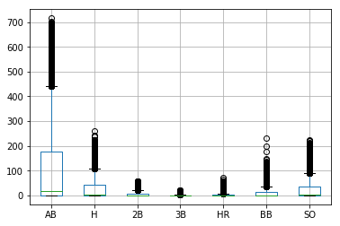

```python
# DataFrame.boxplot(column=None, by=None, ax=None, fontsize=None, rot=0, grid=True, figsize=None, layout=None,
# return_type=None, **kwds)

df2k[["AB", "H", "2B", "3B", "HR", "BB", "SO"]].boxplot(figsize=(10, 7))
```

[output not shown]

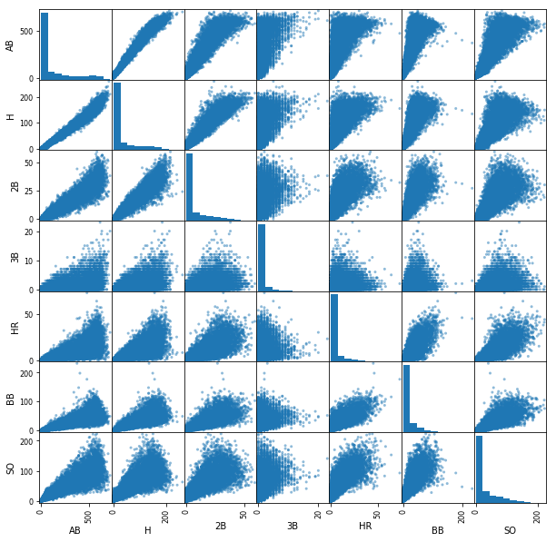

```python
# scatter_matrix(frame, alpha=0.5, figsize=None, ax=None, grid=False, diagonal='hist', marker='.',
#                density_kwds=None, hist_kwds=None, range_padding=0.05, **kwds)
# diagonal: pick between 'kde' and 'hist' for either Kernel Density Estimation or Histogram plot in the diagonal

scatter_matrix(df2k[["AB", "H", "2B", "3B", "HR", "BB", "SO"]], figsize=(10, 10), diagonal="hist")
```

It'd be helpful to see all possible correlations between columns on a single chart.

## Derive Additional Columns

Often times, the raw data does not come with all information we need. We can derive additional columns from existing columns and add them to the original dataframe.

```python
# Batting Average (BA) = H / AB

# df2k["BA"] = df2k["H"] / df2k["AB"]
```

```python
# Batting Average (BA) = H / AB

def divide(number, divisor):
    if divisor == 0:             # handling zero devision
        return 0
    else:
        return number / divisor

df2k["BA"] = df2k.apply(lambda x: divide(x["H"], x["AB"]), axis=1)
```

```python
df2k.head()
```

|  | playerID | yearID | stint | teamID | lgID | G | AB | R | H | 2B | ... | SB | CS | BB | SO | IBB | HBP | SH | SF | GIDP | BA |
| --- | --- | --- | --- | --- | --- | --- | --- | --- | --- | --- | --- | --- | --- | --- | --- | --- | --- | --- | --- | --- | --- |
| 79250 | abbotje01 | 2000 | 1 | CHA | AL | 80 | 215 | 31 | 59 | 15 | ... | 2.0 | 1.0 | 21 | 38.0 | 1.0 | 2.0 | 2.0 | 1.0 | 2.0 | 0.274419 |
| 79251 | abbotku01 | 2000 | 1 | NYN | NL | 79 | 157 | 22 | 34 | 7 | ... | 1.0 | 1.0 | 14 | 51.0 | 2.0 | 1.0 | 0.0 | 1.0 | 2.0 | 0.216561 |
| 79252 | abbotpa01 | 2000 | 1 | SEA | AL | 35 | 5 | 1 | 2 | 1 | ... | 0.0 | 0.0 | 0 | 1.0 | 0.0 | 0.0 | 1.0 | 0.0 | 0.0 | 0.400000 |
| 79253 | abreubo01 | 2000 | 1 | PHI | NL | 154 | 576 | 103 | 182 | 42 | ... | 28.0 | 8.0 | 100 | 116.0 | 9.0 | 1.0 | 0.0 | 3.0 | 12.0 | 0.315972 |
| 79254 | aceveju01 | 2000 | 1 | MIL | NL | 62 | 1 | 1 | 0 | 0 | ... | 0.0 | 0.0 | 1 | 1.0 | 0.0 | 0.0 | 0.0 | 0.0 | 0.0 | 0.000000 |

5 rows × 23 columns

```python
# Slugging Average (SLG) = (singles + (2 * doubles) + (3 * triples) + (4 * HR)) / AB

def get_SLG(series):
    doubles = series["2B"]
    triples = series["3B"]
    HR = series["HR"]
    singles = series["H"] - (doubles + triples + HR)
    AB = series["AB"]

    if AB == 0:
        return 0
    else:
        return (singles + (2 * doubles) + (3 * triples) + (4 * HR)) / AB

df2k["SLG"] = df2k.apply(lambda x: get_SLG(x), axis=1)
```

```python
df2k.head()
```

|  | playerID | yearID | stint | teamID | lgID | G | AB | R | H | 2B | ... | CS | BB | SO | IBB | HBP | SH | SF | GIDP | BA | SLG |
| --- | --- | --- | --- | --- | --- | --- | --- | --- | --- | --- | --- | --- | --- | --- | --- | --- | --- | --- | --- | --- | --- |
| 79250 | abbotje01 | 2000 | 1 | CHA | AL | 80 | 215 | 31 | 59 | 15 | ... | 1.0 | 21 | 38.0 | 1.0 | 2.0 | 2.0 | 1.0 | 2.0 | 0.274419 | 0.395349 |
| 79251 | abbotku01 | 2000 | 1 | NYN | NL | 79 | 157 | 22 | 34 | 7 | ... | 1.0 | 14 | 51.0 | 2.0 | 1.0 | 0.0 | 1.0 | 2.0 | 0.216561 | 0.388535 |
| 79252 | abbotpa01 | 2000 | 1 | SEA | AL | 35 | 5 | 1 | 2 | 1 | ... | 0.0 | 0 | 1.0 | 0.0 | 0.0 | 1.0 | 0.0 | 0.0 | 0.400000 | 0.600000 |
| 79253 | abreubo01 | 2000 | 1 | PHI | NL | 154 | 576 | 103 | 182 | 42 | ... | 8.0 | 100 | 116.0 | 9.0 | 1.0 | 0.0 | 3.0 | 12.0 | 0.315972 | 0.553819 |
| 79254 | aceveju01 | 2000 | 1 | MIL | NL | 62 | 1 | 1 | 0 | 0 | ... | 0.0 | 1 | 1.0 | 0.0 | 0.0 | 0.0 | 0.0 | 0.0 | 0.000000 | 0.000000 |

5 rows × 24 columns

## Prepare Data for Modeling

```python
features = ["G", "AB", "R", "BA", "SLG"]
target = "HR"

X = df2k[features]
y = df2k[target]
```

Data is usually denoted with a capital X, while target labels are denoted by a lowercase y. We use a capital X when the data is a two-dimensional array (or a matrix) and a lowercase y when the target is a one-dimensional array (or a vector).

```python
X.head()
```

|  | G | AB | R | BA | SLG |
| --- | --- | --- | --- | --- | --- |
| 79250 | 80 | 215 | 31 | 0.274419 | 0.395349 |
| 79251 | 79 | 157 | 22 | 0.216561 | 0.388535 |
| 79252 | 35 | 5 | 1 | 0.400000 | 0.600000 |
| 79253 | 154 | 576 | 103 | 0.315972 | 0.553819 |
| 79254 | 62 | 1 | 1 | 0.000000 | 0.000000 |

```python
y.head()
```

```
79250     3
79251     6
79252     0
79253    25
79254     0
Name: HR, dtype: int64
```

```python
# train_test_split(*arrays, **options)
# Split arrays or matrices into random train and test subsets

X_train, X_test, y_train, y_test = train_test_split(X, y, test_size=0.25, random_state=0)
```

```python
X_train.shape
```

```
(17674, 5)
```

```python
X_test.shape
```

```
(5892, 5)
```

```python
y_train.shape
```

```
(17674,)
```

```python
y_test.shape
```

```
(5892,)
```

## Modeling with k-Nearest Neigobors (k-NN)

```python
# KNeighborsRegressor(n_neighbors=5, weights='uniform', algorithm='auto', leaf_size=30, p=2, metric='minkowski',
#                     metric_params=None, n_jobs=1, **kwargs)

knn = KNeighborsRegressor(n_neighbors=1)
```

```python
knn.fit(X_train, y_train)
```

```
KNeighborsRegressor(algorithm='auto', leaf_size=30, metric='minkowski',
          metric_params=None, n_jobs=1, n_neighbors=1, p=2,
          weights='uniform')
```

```python
knn.score(X_train, y_train)
```

```
0.99994798097824744
```

Every score method in scikit-learn returns the $R^2$ score, which is a measure of goodness of a prediction for a regression model. A value of 1 corresponds to a perfect prediction, and a value of 0 to a constant model that just predicts the mean of the training set responses, y_train.

```python
knn.score(X_test, y_test)
```

```
0.62556656288131329
```

```python
batter = {"G": 130,
          "AB": 450,
          "R": 100,
          "BA": 0.3,
          "SLG": 0.6}

X_new = [[batter["G"], batter["AB"], batter["R"], batter["BA"], batter["SLG"]]]
knn.predict(X_new)
```

```
array([ 42.])
```

```python
ks = range(1, 21)     # ks = [1, 2, 3, ..., 20]
train_scores = []
test_scores = []

for k in ks:
    print("k = {0}".format(k))
    knn = KNeighborsRegressor(n_neighbors=k)
    knn.fit(X_train, y_train)

    train_score = knn.score(X_train, y_train)
    test_score = knn.score(X_test, y_test)

    train_scores.append(train_score)
    test_scores.append(test_score)

    print("%.2f" %train_score)
    print("%.2f" %test_score)
    print()
```

```
k = 1
1.00
0.63

k = 2
0.90
0.71

k = 3
0.86
0.75

k = 4
0.85
0.77

k = 5
0.84
0.78

k = 6
0.83
0.78

k = 7
0.82
0.79

k = 8
0.82
0.79

k = 9
0.82
0.79

k = 10
0.81
0.80

```

[output cut: 24 more lines]

```
k = 17
0.80
0.80

k = 18
0.80
0.80

k = 19
0.80
0.80

k = 20
0.80
0.80
```

When using multiple nearest neighbors, the prediction is the average, or mean, of the relevant neighbors.

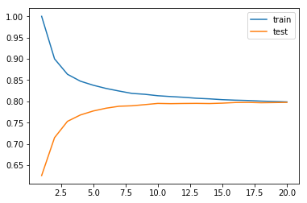

```python
plt.plot(ks, train_scores, label="train")
plt.plot(ks, test_scores, label="test")
legend()
plt.show()
```

As *k* grows, the training score is gradually decreasing, while the test score is gradually increasing, but both eventually converging to some value around 0.8.

```python
knn_best = KNeighborsRegressor(n_neighbors=10)
knn_best.fit(X_train, y_train)
```

```
KNeighborsRegressor(algorithm='auto', leaf_size=30, metric='minkowski',
          metric_params=None, n_jobs=1, n_neighbors=10, p=2,
          weights='uniform')
```

```python
knn_best.score(X_test, y_test)
```

```
0.79514518082714458
```

## Modeling with Linear Regression

```python
# LinearRegression(fit_intercept=True, normalize=False, copy_X=True, n_jobs=1)

lr = LinearRegression()
```

```python
lr.fit(X_train, y_train)
```

```
LinearRegression(copy_X=True, fit_intercept=True, n_jobs=1, normalize=False)
```

```python
lr.coef_
```

```
array([  2.98669511e-03,  -8.11528659e-03,   2.80144763e-01,
        -1.91175658e+01,   1.33826489e+01])
```

```python
for feature, coef in zip(features, lr.coef_):    # zip iterates over two lists taking one element at a time from each of the two lists.
    print(feature, "%.2f" %(coef))
```

```
G 0.00
AB -0.01
R 0.28
BA -19.12
SLG 13.38
```

You would want to interpret that BA has a negative impact on HR, while SLG has a positive impact. Unfortunately, however, it's often not entirely clear why coefficients are the way they are. This is particularly true if the dataset has highly correlated features; in theses cases, the coefficients may be hard to interpret.

```python
lr.score(X_train, y_train)
```

```
0.78960224431501469
```

```python
lr.score(X_test, y_test)
```

```
0.80590720668114824
```

```python
X_new = [[batter["G"], batter["AB"], batter["R"], batter["BA"], batter["SLG"]]]
lr.predict(X_new)
```

```
array([ 26.89687447])
```

## Handle Underfitting by Adding Polynomial Features

If you think your model is underfitted, which means the model is too simple, you can consider adding polynomial features, i.e., polynomial combinations of existing features.

```python
from sklearn.datasets import load_boston
boston = load_boston()
boston.keys()
```

```
dict_keys(['data', 'target', 'feature_names', 'DESCR'])
```

```python
print(boston.DESCR)
```

```
Boston House Prices dataset
===========================

Notes
------
Data Set Characteristics:

    :Number of Instances: 506

    :Number of Attributes: 13 numeric/categorical predictive

    :Median Value (attribute 14) is usually the target

    :Attribute Information (in order):
        - CRIM     per capita crime rate by town
        - ZN       proportion of residential land zoned for lots over 25,000 sq.ft.
        - INDUS    proportion of non-retail business acres per town
        - CHAS     Charles River dummy variable (= 1 if tract bounds river; 0 otherwise)
        - NOX      nitric oxides concentration (parts per 10 million)
        - RM       average number of rooms per dwelling
        - AGE      proportion of owner-occupied units built prior to 1940
        - DIS      weighted distances to five Boston employment centres
        - RAD      index of accessibility to radial highways
        - TAX      full-value property-tax rate per $10,000
        - PTRATIO  pupil-teacher ratio by town
        - B        1000(Bk - 0.63)^2 where Bk is the proportion of blacks by town
        - LSTAT    % lower status of the population
        - MEDV     Median value of owner-occupied homes in $1000's

    :Missing Attribute Values: None

    :Creator: Harrison, D. and Rubinfeld, D.L.

This is a copy of UCI ML housing dataset.
http://archive.ics.uci.edu/ml/datasets/Housing


This dataset was taken from the StatLib library which is maintained at Carnegie Mellon University.

The Boston house-price data of Harrison, D. and Rubinfeld, D.L. 'Hedonic
prices and the demand for clean air', J. Environ. Economics & Management,
vol.5, 81-102, 1978.   Used in Belsley, Kuh & Welsch, 'Regression diagnostics
...', Wiley, 1980.   N.B. Various transformations are used in the table on
pages 244-261 of the latter.

The Boston house-price data has been used in many machine learning papers that address regression
problems.

**References**

   - Belsley, Kuh & Welsch, 'Regression diagnostics: Identifying Influential Data and Sources of Collinearity', Wiley, 1980. 244-261.
   - Quinlan,R. (1993). Combining Instance-Based and Model-Based Learning. In Proceedings on the Tenth International Conference of Machine Learning, 236-243, University of Massachusetts, Amherst. Morgan Kaufmann.
   - many more! (see http://archive.ics.uci.edu/ml/datasets/Housing)
```

```python
boston.feature_names
```

```
array(['CRIM', 'ZN', 'INDUS', 'CHAS', 'NOX', 'RM', 'AGE', 'DIS', 'RAD',
       'TAX', 'PTRATIO', 'B', 'LSTAT'],
      dtype='<U7')
```

```python
boston.data
```

```
array([[  6.32000000e-03,   1.80000000e+01,   2.31000000e+00, ...,
          1.53000000e+01,   3.96900000e+02,   4.98000000e+00],
       [  2.73100000e-02,   0.00000000e+00,   7.07000000e+00, ...,
          1.78000000e+01,   3.96900000e+02,   9.14000000e+00],
       [  2.72900000e-02,   0.00000000e+00,   7.07000000e+00, ...,
          1.78000000e+01,   3.92830000e+02,   4.03000000e+00],
       ...,
       [  6.07600000e-02,   0.00000000e+00,   1.19300000e+01, ...,
          2.10000000e+01,   3.96900000e+02,   5.64000000e+00],
       [  1.09590000e-01,   0.00000000e+00,   1.19300000e+01, ...,
          2.10000000e+01,   3.93450000e+02,   6.48000000e+00],
       [  4.74100000e-02,   0.00000000e+00,   1.19300000e+01, ...,
          2.10000000e+01,   3.96900000e+02,   7.88000000e+00]])
```

```python
boston.target
```

[output not shown]

```python
X = boston.data
y = boston.target
```

```python
X_train, X_test, y_train, y_test = train_test_split(X, y, random_state=0)
```

```python
lr.fit(X_train, y_train)
```

```
LinearRegression(copy_X=True, fit_intercept=True, n_jobs=1, normalize=False)
```

```python
lr.score(X_train, y_train)
```

```
0.76974483705639385
```

```python
lr.score(X_test, y_test)
```

```
0.63536207866747119
```

Both the scores on the training set and the test set are too low, which means we are likely underfitting.

```python
# PolynomialFeatures(degree=2, interaction_only=False, include_bias=True)

poly = PolynomialFeatures(degree=2)
```

PolynomialFeatures generates a new feature matrix consisting of all polynomial combinations of the features with degree less than or equal to the specified degree. For example, if an input sample is two dimensional and of the form [a, b], the degree-2 polynomial features are [1, a, b, a^2, a*b, b^2].

```python
X_poly = poly.fit_transform(X)
```

```python
X.shape, X_poly.shape
```

```
((506, 13), (506, 105))
```

```python
X_train, X_test, y_train, y_test = train_test_split(X_poly, y, random_state=0)
```

```python
lr.fit(X_train, y_train)
```

```
LinearRegression(copy_X=True, fit_intercept=True, n_jobs=1, normalize=False)
```

```python
lr.score(X_train, y_train)
```

```
0.93914682062682842
```

```python
lr.score(X_test, y_test)
```

```
0.58754847887536621
```

Now the trainig score gets very high, while the test score is still low (gets even worse). This discrepancy between those two scores is a clear sign of overfitting.

## Handle Overfitting Using Regularization

```python
# Ridge(alpha=1.0, fit_intercept=True, normalize=False, copy_X=True, max_iter=None, tol=0.001, solver='auto', random_state=None)

ridge = Ridge(alpha=1.0)
```

- alpha = 0 : make the model the same as simple linear regression
- increase alpha: make coefficients to move toward zero, which decreases training score but may help generalization
- alpha = ∞ : make all the coefficients zero

```python
ridge.fit(X_train, y_train)
```

```
Ridge(alpha=1.0, copy_X=True, fit_intercept=True, max_iter=None,
   normalize=False, random_state=None, solver='auto', tol=0.001)
```

```python
ridge.score(X_train, y_train)
```

```
0.94836985516129513
```

```python
ridge.score(X_test, y_test)
```

```
0.60574032573472003
```

```python
alphas = [0, 0.01, 0.03, 0.1, 0.3, 1, 3, 10, 30, 100, 300]
train_scores = []
test_scores = []
best_score = 0

for alpha in alphas:
    print("alpha = {0}".format(alpha))
    ridge = Ridge(alpha=alpha)
    ridge.fit(X_train, y_train)

    train_score = ridge.score(X_train, y_train)
    test_score = ridge.score(X_test, y_test)

    train_scores.append(train_score)
    test_scores.append(test_score)

    # Keep track of the best test score and its corresponding parameters
    if test_score > best_score:
        best_score = test_score
        best_parameters = {"alpha": alpha}

    print("%.2f" %train_score)
    print("%.2f" %test_score)
    print()
```

```
alpha = 0
0.95
0.61

alpha = 0.01
0.95
0.57

alpha = 0.03
0.95
0.56

alpha = 0.1
0.95
0.57

alpha = 0.3
0.95
0.58

alpha = 1
0.95
0.61

alpha = 3
0.95
0.65

alpha = 10
0.94
0.72

alpha = 30
0.94
0.75

alpha = 100
0.93
0.75

alpha = 300
0.93
0.75
```

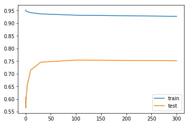

```python
plt.plot(alphas, train_scores, label="train")
plt.plot(alphas, test_scores, label="test")
legend()
plt.show()
```

```python
best_score, best_parameters
```

```
(0.75423024982712805, {'alpha': 100})
```

```python
ridge_best = Ridge(**best_parameters)
ridge_best.fit(X_train, y_train)
```

```
Ridge(alpha=100, copy_X=True, fit_intercept=True, max_iter=None,
   normalize=False, random_state=None, solver='auto', tol=0.001)
```

```python
ridge_best.score(X_test, y_test)
```

```
0.75423024982722864
```